# Precept 4

Student von Student III

In this handout, we will learn how to calculate correlations, plot points of different colors and types, and add a line to a scatterplot.

## Topics and Concepts Covered

- Calculating a correlation coefficient
- Fitting a linear model
- Creating a scatterplot
- Adding a regression line
- Setting the color of points
- Setting the character plotted
- *Auto-correlation*. The correlation between a variable and its lagged value
- *Panel data*. A data structure where we observe each of the same set of units at the same time, over multiple time periods

## R Commands Covered

- Calculating correlation coefficients with `cor`
- Estimating a linear model with `lm`
- Creating a scatterplot through `plot`
- Adjusting the color of points by setting the value of `col`
- Adjusting the character plotted by setting the value `pch`

**Before beginning this handout, Do not forget to make a new folder for this assignment and set your working directory!**

# Introduction to Data

To study sovereign debt and economic growth, the economists Carmen Reinhart and Ken Rogoff (Reinhart and Rogoff 2010) have constructed an impressive data set that encompasses over 70 countries and 800 years worth of observations including variables such as inflation, exchange rates, debt-to-GDP ratios and categorical variables indicating whether a country is suffering from a debt, inflation or banking crisis. While the research is multi-faceted, the aspect that has received the most public attention is the claim that once a country’s debt-to-GDP ratio crosses a threshold of approximately 90%, growth rates plummet.

This argument is not strictly academic; policy makers in both the US and Europe have been arguing over whether the current economic downturn should be greeted with more or less government spending, viewpoints I will be referring to as “Keynesian” and “austerian.” In a nutshell, the Keynesian argument is that governments should spend less during times of economic growth and more during times of economic downturn. Normally, this process is handled by the Federal Reserve, through adjusting interest rates (through buying or selling US Treasury Bonds).

At the moment, interest rates are approximately zero. Since the Federal Reserve cannot lower interest rates below zero, the Fed’s direct policy interventions have been exhausted (QE1 and QE2 are indirect). Government spending is the only alternative when interest rates are at zero, since private spending is not able to fill the output gap in the short-run. The Keynesians argue that the government should assume more debt when interest rates are around zero, to fill this output gap.

The austerian argument leads to the opposite policy prescription. Austerians argue that spending through deficit-financing will lead to the accumulation of more debt, increasing the risk of future sovereign default. This increase in risk will raise interest rates in the future. Since these future expectations are factored into today’s investment and consumption decisions, increasing debt will place an upward pressure on *present* interest rates, slowing down current growth.

The following articles help explain the data and the debate involved. You don’t have to focus on details, but these articles do give some useful background for really understanding this analysis:

- The original paper positing the 90% threshold: Reinhart and Rogoff (2010)
- Herndon et al.’s reply: Herndon, Ash, and Pollin (2014) You should focus on the first 10 pages or so
- Stephen Colbert [weighs in](http://www.colbertnation.com/the-colbert-report-videos/425748/april-23-2013/austerity-s-spreadsheet-error?xrs=share_copy) on the issue

A few more resources, if you find the topic interesting, are:

- Reinhart and Rogoff [respond](http://www.nytimes.com/2013/04/26/opinion/debt-growth-and-the-austerity-debate.html?pagewanted=all) in the New York Times to the Herndon et al. paper
- Herndon’s co-authors [respond to their response](http://www.nytimes.com/2013/04/30/opinion/debt-and-growth-a-response-to-reinhart-and-rogoff.html?_r=0), also in the New York Times
- An early critique by Irons and Bivens: (Irons and Bivens 2010) [(link)](http://www.epi.org/page/-/pdf/BP271.pdf). See especially the section on causality
- A [blog post](http://www.nextnewdeal.net/rortybomb/researchers-finally-replicated-reinhart-rogoff-and-there-are-serious-problems) and [follow up](http://www.nextnewdeal.net/rortybomb/reinhart-rogoff-week-later-why-does-matter) on ‘Rortybomb’ laying out the issues involved

## Correlations and Linear Models

You will find the file `RR.handout.csv` in the data folder next to this document. The file contains all the variables considered by Herndon et al. We will focus on just the following variables:

- `Country`. Country name
- `Year`. Year of observation
- `dRGDP` Percent difference in real GDP (i.e. inflation-adjusted) from last year to the *current* year
- `debtgdp` The Debt-to-GDP ratio for the *current* year
- `lag.dRGDP` The percentage difference in real GDP (i.e. inflation-adjusted) from last year to the *previous* year
- `lag.debtgdp` The Debt-to-GDP ratio for the *previous* year

The data is an example of **panel data**, a type of data where the same observations are made over multiple time periods. Identifying causal effects in panel data, such as estimating whether GDP shifts affect debt, vice versa, neither, or both, is among the trickiest of problems in social science. In this handout, we’re going to conduct an analysis that (begins) to help address this causal question.

First, we read in the data, and make sure we loaded it in properly.

```r
RR <- read.csv("data/RR.handout.csv")
head(RR)
```

```
    Country Year     dRGDP   debtgdp lag.dRGDP lag.debtgdp
1 Australia 1947 2.4594746 177.32137 -3.557951   190.41908
2 Australia 1948 6.4375341 148.92981  2.459475   177.32137
3 Australia 1949 6.6119938 125.82870  6.437534   148.92981
4 Australia 1950 6.9202012 109.80940  6.611994   125.82870
5 Australia 1951 4.2726115  87.09448  6.920201   109.80940
6 Australia 1952 0.9046516  86.06644  4.272612    87.09448
```

```r
summary(RR)
```

```
        Country         Year          dRGDP           debtgdp
 Australia  : 63   Min.   :1947   Min.   :-9.922   Min.   :  3.279
 Canada     : 63   1st Qu.:1965   1st Qu.: 1.919   1st Qu.: 22.148
 Finland    : 63   Median :1981   Median : 3.258   Median : 40.401
 New Zealand: 63   Mean   :1980   Mean   : 3.389   Mean   : 45.916
 Norway     : 63   3rd Qu.:1995   3rd Qu.: 5.065   3rd Qu.: 61.385
 Sweden     : 63   Max.   :2009   Max.   :18.902   Max.   :237.941
 (Other)    :769
   lag.dRGDP        lag.debtgdp
 Min.   :-10.942   Min.   :  3.279
 1st Qu.:  1.981   1st Qu.: 22.083
 Median :  3.319   Median : 40.389
 Mean   :  3.538   Mean   : 46.172
 3rd Qu.:  5.109   3rd Qu.: 61.474
 Max.   : 27.329   Max.   :247.482
```

## Correlations and the Line of Best Fit

Calculating correlations in R is done with the `cor` function. It takes two arguments `x` and `y`, as

> `cor(x, y)`

For example, if we wanted to know the correlation between current change in GDP and the current debt ratio, we would use

```r
cor(RR$debtgdp, RR$dRGDP)
```

```
[1] -0.1914904
```

which gives a correlation of approximately -0.19. So, current debt and current growth show a negative relationship. We could also look at the correlation between past and current levels of debt:

```r
cor(RR$debtgdp, RR$lag.debtgdp)
```

```
[1] 0.9892828
```

and growth:

```r
cor(RR$dRGDP, RR$lag.dRGDP)
```

```
[1] 0.4088232
```

It appears that debt is highly *autocorrelated*. In other words, its past and current values correlate at a really high level. The problem is less acute (though still present) for growth rates.

Autocorrelation creates a problem in inference, as it becomes difficult to disentangle whether the causal effect is driven by the *current* levels or *past* levels of the variable. When the correlation is so high, it becomes easy to confuse one effect with the other. One common way of reducing autocorrelation is to take a “first difference”:

```r
cor(RR$debtgdp - RR$lag.debtgdp, RR$lag.debtgdp)
```

```
[1] -0.2403264
```

The first difference of debt (`RR\$debtgdp - RR\$lag.debtgdp`) correlates with previous debt at about $-0.24$, which is much less (in magnitude) than the original correlation of approximately $0.99$.

Calculating linear models in R is done using the `lm` function. It takes one “formula” argument that connects one variable y to one (or more) variables x, as

> `lm(y ~ x)`

Here, y is the outcome, or dependent, variable and x is a single independent variable. As mentioned above, the argument passed to the `lm` function is of the form `y ~ x`, where `~` shows that it is a formula. In other words, we are assuming, for observation $y_i$, a model of the form
$$y_i = \alpha + \beta x_i + \epsilon_i$$
The `lm` function allows us to estimate the coefficients $\widehat \alpha$ and $\widehat \beta$ such that the line is as close to the data as possible.

For example, let’s say we wanted to find the line of best fit from regressing GDP growth on debt ratios.

```r
lm1 <- lm(RR$dRGDP ~ RR$debtgdp)
lm1
```

```
Call:
lm(formula = RR$dRGDP ~ RR$debtgdp)

Coefficients:
(Intercept)   RR$debtgdp
    4.17512     -0.01713
```

where `lm1` is an object that contains all the information we need about the linear regression. According to our model, the estimated marginal effect of a one percent increase debt ratio on GDP growth is captured by the estimated coefficient $\widehat \beta \approx -0.017$.

If we wanted to access the coefficients from the regression, we can use them directly within `lm1` object

```r
lm1$coef # Both coefficients
```

```
(Intercept)  RR$debtgdp
  4.1751238  -0.0171267
```

```r
lm1$coef[1] # The intercept
```

```
(Intercept)
   4.175124
```

```r
lm1$coef[2] # The slope
```

```
RR$debtgdp
-0.0171267
```

or we could use the `coef` function to take a copy of the model coefficients

```r
mycoefs <- coef(lm1) # Both coefficients
mycoefs
```

```
(Intercept)  RR$debtgdp
  4.1751238  -0.0171267
```

```r
mycoefs[1] # The intercept
```

```
(Intercept)
   4.175124
```

```r
mycoefs[2] # The slope
```

```
RR$debtgdp
-0.0171267
```

# Adding a Regression Line and Coloring Points in a Figure

In this section, we are going to create scatterplots, which are a plot of a variable $x$ against a variable $y$. We will then change the color and plotting character of subsets of the points, and then add a regression line to the figure.

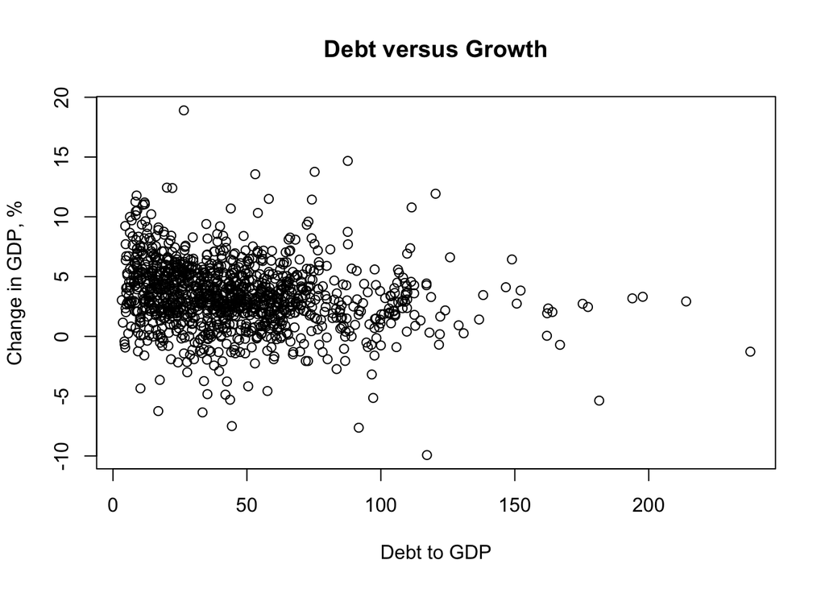

```r
plot(RR$debtgdp, RR$dRGDP,
     xlab = "Debt to GDP", ylab = "Change in GDP, %",
     main = "Debt versus Growth")
```

Recall that we have the object `lm1` defined above. We can add this line to the plot using the `abline` function

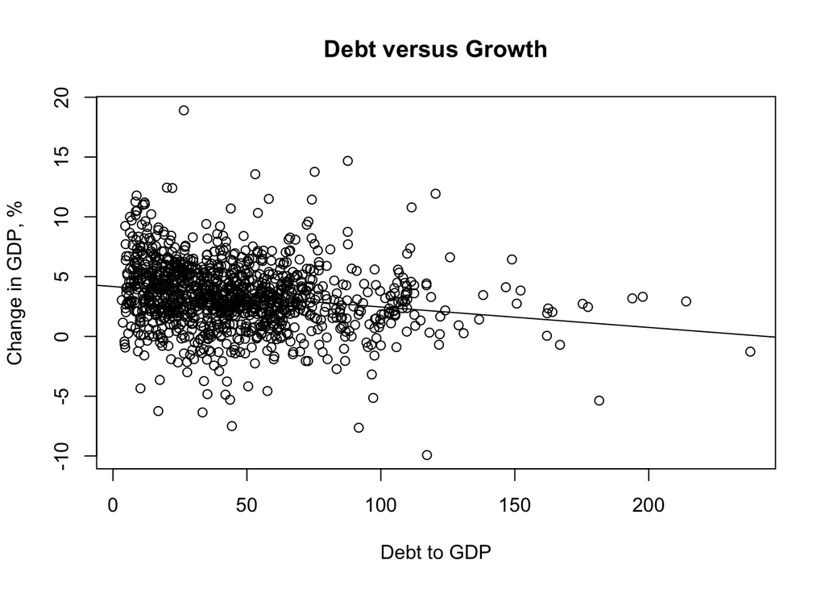

```r
plot(RR$debtgdp, RR$dRGDP,
     xlab = "Debt to GDP", ylab = "Change in GDP, %",
     main = "Debt versus Growth")
abline(lm1)
```

### Coding tip

Be careful when adding a line to a figure! The plot command takes the form

> `plot(x, y)`

while the two variables in the formula you give to `lm` are in the opposite order:

> `lm(y ~ x)`

Next, we are going to add some color to the figure. We can do this by specifying a color with `col`:

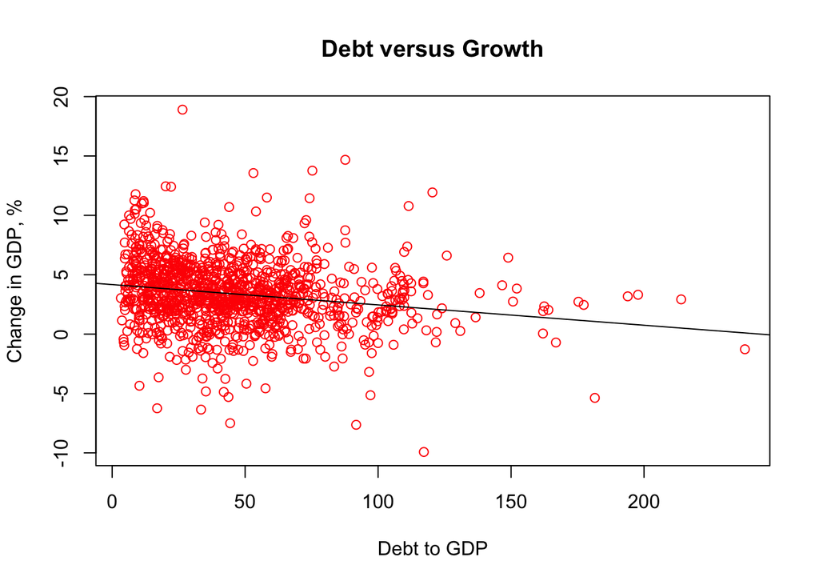

```r
plot(RR$debtgdp, RR$dRGDP,
     xlab = "Debt to GDP", ylab = "Change in GDP, %",
     main = "Debt versus Growth", col = "red")
abline(lm1)
```

We can make the figure more interesting by giving different subsets of the data their own color.

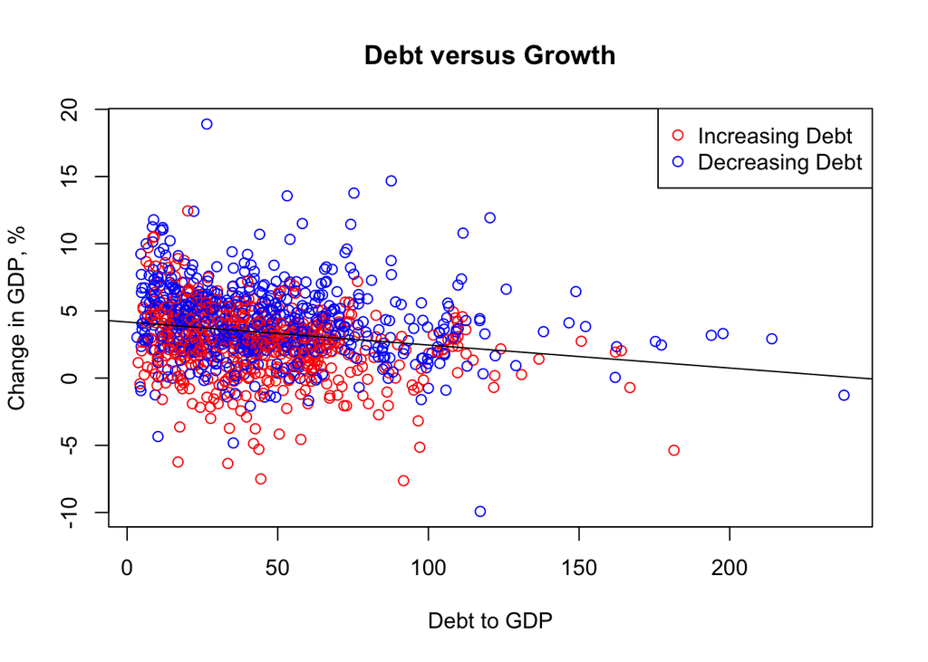

```r
col.plot <- ifelse(RR$debtgdp > RR$lag.debtgdp, "red", "blue")

plot(RR$debtgdp, RR$dRGDP,
     xlab = "Debt to GDP", ylab = "Change in GDP, %",
     main = "Debt versus Growth", col = col.plot)
abline(lm1)
legend(c("topright"), c("Increasing Debt", "Decreasing Debt"),
       col = c( "red", "blue"), pch = 1)
```

Notice that the legend took the option `pch`. This command is short for `plotting character`, and controls the type of character plotted on the figure. We are going to use two different numbers for `pch`

- 1. The default, an open circle
- 19. A solid circle
- “A”, “f”, etc. This will use the letter A or f as the point character

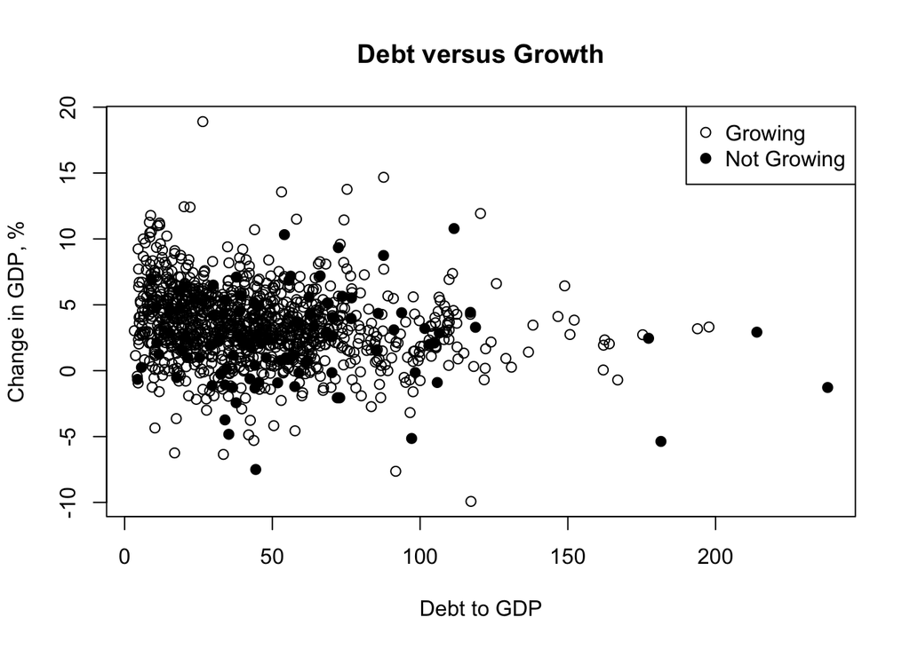

```r
pch.plot <- ifelse(RR$lag.dRGDP > 0, 1, 19)

plot(RR$debtgdp, RR$dRGDP,
     xlab = "Debt to GDP", ylab = "Change in GDP, %",
     main = "Debt versus Growth", pch = pch.plot)
legend(c("topright"), c("Growing", "Not Growing"),
       pch = c(1, 19))
```

# Debt and GDP: Exploring the Relationship

In this section, we are going to make a figure with one row and two columns.  
The two figures will plot

- *Current* debt ratio versus *current growth* for countries with increasing debt and *high* previous growth
- *Current* debt ratio versus *current growth* for countries with increasing debt and *low* previous growth

The code is below.

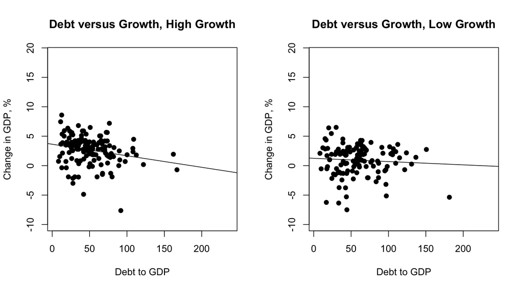

```r
par(mfrow = c(1, 2))

growdebt1 <- (RR$debtgdp - RR$lag.debtgdp > 2) & (RR$lag.dRGDP > 2)
plot(RR$debtgdp[growdebt1], RR$dRGDP[growdebt1],
     xlab = "Debt to GDP", ylab  =  "Change in GDP, %",
     main = "Debt versus Growth, High Growth", pch = 19,
     ylim = range(RR$dRGDP), xlim = range(RR$debtgdp))
abline(lm(RR$dRGDP[growdebt1] ~ RR$debtgdp[growdebt1]))

growdebt2 <- (RR$debtgdp - RR$lag.debtgdp > 2) & (RR$lag.dRGDP <= 2)
plot(RR$debtgdp[growdebt2], RR$dRGDP[growdebt2],
     xlab = "Debt to GDP", ylab  =  "Change in GDP, %",
     main = "Debt versus Growth, Low Growth", pch = 19,
     ylim = range(RR$dRGDP), xlim = range(RR$debtgdp))
abline(lm(RR$dRGDP[growdebt2] ~ RR$debtgdp[growdebt2]))
```

The slope in the left hand figure, for countries with high previous growth, is steeper than the slope on the right. From the difference between these two slopes, we can deduce the following: for countries with growing debt levels, countries with higher previous growth rates are more sensitive to debt than countries with low previous growth rates.

# Precept Problems

### Question 1

Create a figure similar to that in the previous section exploring the relationship between debt and GDP. Operationalize ‘increasing growth’ as in increase in the GDP growth rate from the previous to current year of 2 or more percentage points and  
*high* and *low* previous debt as previous debt levels above or below 70.

Now You are going to make a figure with one row and two columns. The two figures will plot:

- *Current* debt ratio versus *current growth* for countries with increasing growth and *high* previous debt
- *Current* debt ratio versus *current growth* for countries with increasing growth and *low* previous debt

### Question 2

What is the difference in slopes between the lines in the left and right figures in the example (oin the secton above)? In the left and right hand figures from Question 1?

## Question 3

Is the relationship between debt and GDP more sensitive to changes in previous growth rates (in the section above) of previous shifts in the debt ratio (Question 1)?

Does this suggest

- debt ratios have a causal effect on growth rates
- growth rates have a causal effect on debt ratios
- neither
- both

Please keep in mind, there is no right answer to this question, just well-reasoned and less well-reasoned responses. Also, this is a tricky question to reason through. Give it a shot.

### Question 4

The cutoffs we selected, 70% for debt and 2% for growth, were arbitrary. Are the results robust to different values for the debt cutoff and growth cutoff?  
Make another figure with different cutoffs.

# References

Herndon, T., M. Ash, and R. Pollin. 2014. “Does High Public Debt Consistently Stifle Economic Growth? A Critique of Reinhart and Rogoff.” *Cambridge Journal of Economics* 38 (2): 257–79. doi:10.1093/cje/bet075.

Irons, John, and Josh Bivens. 2010. “Government Debt and Economic Growth: Overreaching Claims of Debt ‘Threshold’ Suffer from Theoretical and Empirical Flaws.” EPI Briefing Paper 271. Economic Policy Institute.

Reinhart, Carmen M., and Kenneth S. Rogoff. 2010. “Growth in a Time of Debt.” *American Economic Review* 100 (2): 573–78. doi:10.1257/aer.100.2.573.